# Price Optimisation: Can we find an optimial price for every product of a Cafe, that would maximise profits?

Pricing a product is a crucial aspect in any business. Alot of thought process is out into it. There are different strategies to price different kinds of products. There are products whose sales are quite sensitive to their prices and as such a small change in their price can lead to noticeable change in their sales. While there are products whose sales are not much affected by their price - these tend to be either luxury items or necessities (like certain medicines). This notebook will focus on the former type of products.

Price elasticity of demand (Epd), or elasticity, is the degree to which the effective desire for something changes as its price changes. In general, people desire things less as those things become more expensive. However, for some products, the customer's desire could drop sharply even with a little price increase, and for other products, it could stay almost the same even with a big price increase. Economists use the term elasticity to denote this sensitivity to price increases. More precisely, price elasticity gives the percentage change in quantity demanded when there is a one percent increase in price, holding everything else constant.

Mathematically speaking, the price elasticity of demand is defined to be the percentage change in quantity demanded, q,divided by the percentage change in price, p. The formula for the price elasticity (ǫ) is: $$e = \%ΔQ/ \%ΔP$$

In this work, we shall look at the sales of the items of a cafe. *Do we see price elasticity for our product? Can we find an optimal price? Will it depend on certain other factors?*

# Preparation: Packages loading, dataset discovery and understanding

## Load necessary packages

```python
#!pip install dataprep
from statsmodels.stats.outliers_influence import variance_inflation_factor
from dataprep.eda import create_report
import pandas as pd
import numpy as np
import statsmodels.api as sm
from statsmodels.formula.api import ols
from statsmodels.graphics.regressionplots import plot_regress_exog
import matplotlib.pyplot as plt
import seaborn as sns; sns.set(style="ticks", color_codes=True)
import random
```

```python
## Get multiple outputs in the same cell
from IPython.core.interactiveshell import InteractiveShell
InteractiveShell.ast_node_interactivity = "all"

## Ignore all warnings
import warnings
warnings.filterwarnings('ignore')
warnings.filterwarnings(action='ignore', category=DeprecationWarning)
```

## Load the data. Dataset discovery and cleaning

```python
transactions = pd.read_csv('Cafe+-+Transaction+-+Store.csv')
sell_meta_data = pd.read_csv('Cafe+-+Sell+Meta+Data.csv')
date_info = pd.read_csv('Cafe+-+DateInfo.csv')
```

```python
transactions.head(100)
```

|  | CALENDAR_DATE | PRICE | QUANTITY | SELL_ID | SELL_CATEGORY |
| --- | --- | --- | --- | --- | --- |
| 0 | 01/01/12 | 15.50 | 46 | 1070 | 0 |
| 1 | 01/01/12 | 12.73 | 22 | 2051 | 2 |
| 2 | 01/01/12 | 12.75 | 18 | 2052 | 2 |
| 3 | 01/01/12 | 12.60 | 30 | 2053 | 2 |
| 4 | 01/02/12 | 15.50 | 70 | 1070 | 0 |
| ... | ... | ... | ... | ... | ... |
| 95 | 1/24/12 | 12.60 | 56 | 2053 | 2 |
| 96 | 1/25/12 | 15.50 | 100 | 1070 | 0 |
| 97 | 1/25/12 | 12.73 | 38 | 2051 | 2 |
| 98 | 1/25/12 | 12.75 | 26 | 2052 | 2 |
| 99 | 1/25/12 | 12.60 | 60 | 2053 | 2 |

100 rows × 5 columns

*The transactions dataset seems indeed to record all transations occuring in the cafe, especially the time of transaction, the item sold, its price and its quantity*

*How often do the prices vary for every product? Do they vary even during the day? that may help bring further trust in potential causal inference between price of a product, and quantity sold of a product, later down the road*

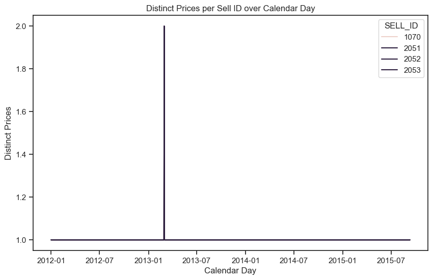

```python
# Assuming your DataFrame is named 'df'
transactions['CALENDAR_DATE'] = pd.to_datetime(transactions['CALENDAR_DATE'])

df = transactions

# Grouping the data by calendar day and sell ID, and counting the distinct prices
grouped_df = df.groupby(['CALENDAR_DATE', 'SELL_ID'])['PRICE'].nunique().reset_index()
grouped_df.rename(columns={'PRICE': 'Distinct_Prices'}, inplace=True)

# Plotting the data
plt.figure(figsize=(10, 6))
sns.lineplot(data=grouped_df, x='CALENDAR_DATE', y='Distinct_Prices', hue='SELL_ID')

plt.title('Distinct Prices per Sell ID over Calendar Day')
plt.xlabel('Calendar Day')
plt.ylabel('Distinct Prices')

plt.show();
```

There is one price per day for every product sold, which makes sense. Except for a single day. That may be potentially interesting if many people came to the shop that day, however in any case I am going to seperate this day from the others, as it is a very unusual behaviour, if not an error. Let's find out on which day it occurs

```python
grouped_df.sort_values(by = 'Distinct_Prices', ascending = False)
```

|  | CALENDAR_DATE | SELL_ID | Distinct_Prices |
| --- | --- | --- | --- |
| 1698 | 2013-03-01 | 2052 | 2 |
| 1699 | 2013-03-01 | 2053 | 2 |
| 1696 | 2013-03-01 | 1070 | 2 |
| 1697 | 2013-03-01 | 2051 | 2 |
| 3601 | 2014-06-20 | 2051 | 1 |
| ... | ... | ... | ... |
| 1798 | 2013-03-26 | 2052 | 1 |
| 1797 | 2013-03-26 | 2051 | 1 |
| 1796 | 2013-03-26 | 1070 | 1 |
| 1795 | 2013-03-25 | 2053 | 1 |
| 5391 | 2015-09-10 | 2053 | 1 |

5392 rows × 3 columns

```python
transactions = transactions[transactions["CALENDAR_DATE"] != '2013-03-01']
transactions_specific_date = transactions[transactions["CALENDAR_DATE"] == '2013-03-01']
```

```python
sell_meta_data.head(100)
```

|  | SELL_ID | SELL_CATEGORY | ITEM_ID | ITEM_NAME |
| --- | --- | --- | --- | --- |
| 0 | 1070 | 0 | 7821 | BURGER |
| 1 | 3055 | 0 | 3052 | COFFEE |
| 2 | 3067 | 0 | 5030 | COKE |
| 3 | 3028 | 0 | 6249 | LEMONADE |
| 4 | 2051 | 2 | 7821 | BURGER |
| 5 | 2051 | 2 | 5030 | COKE |
| 6 | 2052 | 2 | 7821 | BURGER |
| 7 | 2052 | 2 | 6249 | LEMONADE |
| 8 | 2053 | 2 | 7821 | BURGER |
| 9 | 2053 | 2 | 5030 | COKE |
| 10 | 2053 | 2 | 3052 | COFFEE |

```python
unique_items = sell_meta_data['ITEM_NAME'].unique()
print("The cafe sells the following items:")
for item in unique_items:
    print(f"• {item}")
```

```
The cafe sells the following items:
• BURGER
• COFFEE
• COKE
• LEMONADE
```

It also seems, as shown by the different 'sell_category' and 'sell_id' for a same item name, that probably, sell_category = 0 means item sold alone, and sell_category = 0 means items sold in bundle. We can see that with a common sell_id for different item_id. *This enables to show exactly which products are sold within the sell_id in the transactions table. These are the products, the sell id level, for which we will have to try and find a price optimum*

Let's create a new sell info table, at the level of the sell id, and showing all items in the bundle. We will use this table to join with transactions later

```python
# Group by 'SELL_ID' and 'SELL_CATEGORY' and aggregate other columns
products_info = sell_meta_data.groupby(['SELL_ID', 'SELL_CATEGORY']).agg({'ITEM_NAME': list, 'ITEM_ID': list}).reset_index()

# Create new columns for item names and item IDs
products_info['ITEM_NAME_1'] = products_info['ITEM_NAME'].apply(lambda x: x[0] if len(x) >= 1 else '')
products_info['ITEM_NAME_2'] = products_info['ITEM_NAME'].apply(lambda x: x[1] if len(x) >= 2 else '')
products_info['ITEM_NAME_3'] = products_info['ITEM_NAME'].apply(lambda x: x[2] if len(x) >= 3 else '')
products_info['ITEM_ID_1'] = products_info['ITEM_ID'].apply(lambda x: x[0] if len(x) >= 1 else '')
products_info['ITEM_ID_2'] = products_info['ITEM_ID'].apply(lambda x: x[1] if len(x) >= 2 else '')
products_info['ITEM_ID_3'] = products_info['ITEM_ID'].apply(lambda x: x[2] if len(x) >= 3 else '')

# Drop the original 'ITEM_NAME' and 'ITEM_ID' columns
products_info = products_info.drop(['ITEM_NAME', 'ITEM_ID'], axis=1)

# Print the grouped DataFrame
products_info
```

|  | SELL_ID | SELL_CATEGORY | ITEM_NAME_1 | ITEM_NAME_2 | ITEM_NAME_3 | ITEM_ID_1 | ITEM_ID_2 | ITEM_ID_3 |
| --- | --- | --- | --- | --- | --- | --- | --- | --- |
| 0 | 1070 | 0 | BURGER |  |  | 7821 |  |  |
| 1 | 2051 | 2 | BURGER | COKE |  | 7821 | 5030 |  |
| 2 | 2052 | 2 | BURGER | LEMONADE |  | 7821 | 6249 |  |
| 3 | 2053 | 2 | BURGER | COKE | COFFEE | 7821 | 5030 | 3052 |
| 4 | 3028 | 0 | LEMONADE |  |  | 6249 |  |  |
| 5 | 3055 | 0 | COFFEE |  |  | 3052 |  |  |
| 6 | 3067 | 0 | COKE |  |  | 5030 |  |  |

```python
date_info.head(100)
date_info.tail(100)
```

|  | CALENDAR_DATE | YEAR | HOLIDAY | IS_WEEKEND | IS_SCHOOLBREAK | AVERAGE_TEMPERATURE | IS_OUTDOOR |
| --- | --- | --- | --- | --- | --- | --- | --- |
| 0 | 1/1/12 | 2012 | New Year | 1 | 0 | 24.8 | 0 |
| 1 | 1/2/12 | 2012 | New Year | 0 | 0 | 24.8 | 0 |
| 2 | 1/3/12 | 2012 | New Year | 0 | 0 | 32.0 | 1 |
| 3 | 1/4/12 | 2012 | NaN | 0 | 0 | 32.0 | 1 |
| 4 | 1/5/12 | 2012 | NaN | 0 | 0 | 24.8 | 0 |
| ... | ... | ... | ... | ... | ... | ... | ... |
| 95 | 4/6/12 | 2012 | NaN | 0 | 0 | 55.4 | 1 |
| 96 | 4/7/12 | 2012 | NaN | 1 | 0 | 53.6 | 1 |
| 97 | 4/8/12 | 2012 | NaN | 1 | 0 | 55.4 | 1 |
| 98 | 4/9/12 | 2012 | NaN | 0 | 0 | 60.8 | 1 |
| 99 | 4/10/12 | 2012 | NaN | 0 | 0 | 50.0 | 1 |

100 rows × 7 columns

|  | CALENDAR_DATE | YEAR | HOLIDAY | IS_WEEKEND | IS_SCHOOLBREAK | AVERAGE_TEMPERATURE | IS_OUTDOOR |
| --- | --- | --- | --- | --- | --- | --- | --- |
| 1249 | 6/3/15 | 2015 | NaN | 0 | 0 | 78.8 | 1 |
| 1250 | 6/4/15 | 2015 | NaN | 0 | 0 | 78.8 | 1 |
| 1251 | 6/5/15 | 2015 | NaN | 0 | 0 | 82.4 | 1 |
| 1252 | 6/6/15 | 2015 | NaN | 1 | 0 | 71.6 | 1 |
| 1253 | 6/7/15 | 2015 | NaN | 1 | 1 | 75.2 | 1 |
| ... | ... | ... | ... | ... | ... | ... | ... |
| 1344 | 9/6/15 | 2015 | NaN | 1 | 0 | 75.2 | 1 |
| 1345 | 9/7/15 | 2015 | NaN | 0 | 0 | 77.0 | 1 |
| 1346 | 9/8/15 | 2015 | NaN | 0 | 0 | 73.4 | 1 |
| 1347 | 9/9/15 | 2015 | NaN | 0 | 0 | 71.6 | 1 |
| 1348 | 9/10/15 | 2015 | NaN | 0 | 0 | 73.4 | 1 |

100 rows × 7 columns

```python
date_info.describe()
date_info.describe(include = ['O'])
date_info.isnull().sum()

date_info['HOLIDAY'].value_counts()

duplicate_rows = date_info[date_info.duplicated()]
if not duplicate_rows.empty:
    print("Duplicate rows found:")
    print(duplicate_rows)
else:
    print("No duplicate rows found.")
```

|  | YEAR | IS_WEEKEND | IS_SCHOOLBREAK | AVERAGE_TEMPERATURE | IS_OUTDOOR |
| --- | --- | --- | --- | --- | --- |
| count | 1349.000000 | 1349.000000 | 1349.000000 | 1349.000000 | 1349.000000 |
| mean | 2013.375093 | 0.285397 | 0.204596 | 56.326019 | 0.862120 |
| std | 1.073073 | 0.451771 | 0.403556 | 20.227597 | 0.344902 |
| min | 2012.000000 | 0.000000 | 0.000000 | 14.000000 | 0.000000 |
| 25% | 2012.000000 | 0.000000 | 0.000000 | 35.600000 | 1.000000 |
| 50% | 2013.000000 | 0.000000 | 0.000000 | 60.800000 | 1.000000 |
| 75% | 2014.000000 | 1.000000 | 0.000000 | 75.200000 | 1.000000 |
| max | 2015.000000 | 1.000000 | 1.000000 | 87.800000 | 1.000000 |

|  | CALENDAR_DATE | HOLIDAY |
| --- | --- | --- |
| count | 1349 | 105 |
| unique | 1348 | 8 |
| top | 3/1/13 | Luner New Year |
| freq | 2 | 28 |

```
CALENDAR_DATE             0
YEAR                      0
HOLIDAY                1244
IS_WEEKEND                0
IS_SCHOOLBREAK            0
AVERAGE_TEMPERATURE       0
IS_OUTDOOR                0
dtype: int64
```

```
Luner New Year          28
National Day            21
Labor Day               12
Dragon Boat Festivel    12
Qing Ming Festival      12
New Year                10
Mid-Autumn Day           7
WWII Celebration         3
Name: HOLIDAY, dtype: int64
```

```
No duplicate rows found.
```

*The date info table seems to show us some features about every daily date from the first day of January 2012 to the 10th of September 2015. Features such as is it a holiday, is it a school break, the temperature and I would think, if the cafe has opened its outdoor area*

Is weekend looks to be straightforward and is activated when the day is either a Saturday or a Sunday. We see some discrepancies between Holiday and 'Is Schoolbreak', probably SchoolBreak refers to 14 days children break from school that can happen in not Holidays time for regular Adults, let's dive deeper here to make sure. The idea of this work is to make sure we properly understand the features that we have been provided with

```python
schoolbreaks = date_info['IS_SCHOOLBREAK'].sum()
holidays = date_info['HOLIDAY'].notnull().sum()

print(f"In total, over the last 3 years, we had {schoolbreaks} school break days and {holidays} holiday days.")
```

```
In total, over the last 3 years, we had 276 school break days and 105 holiday days.
```

```python
date_info.loc[date_info['HOLIDAY'].notnull() & date_info['IS_SCHOOLBREAK'] == 1,:].shape[0]
```

```
21
```

We can see that these two features are useful, as holidays does not imply school break, and vice versa

*How big are our datasets?*

```python
datasets = [transactions, date_info, sell_meta_data]

for dataset_name, dataset in zip(['transactions', 'date_info', 'sell_meta_data'], datasets):
    print(f"The dataset {dataset_name} is of shape {dataset.shape}")
```

```
The dataset transactions is of shape (5388, 5)
The dataset date_info is of shape (1349, 7)
The dataset sell_meta_data is of shape (11, 4)
```

*Let's create a new single dataset that will put together, along each transactions, the information gathered about the date of the transaction, and the information gathered from the sell info table telling which exact product (signe item or bundle and if so which bundler?) was sold*

before that, let's make sure we don't have any duplicates in the transactions table. We have already checked for the two other tables

```python
num_duplicates = len(transactions[transactions.duplicated()])
transactions = transactions.drop_duplicates()

if num_duplicates > 0:
    print(f"{num_duplicates} duplicate rows found and removed.")
else:
    print("No duplicate rows found.")
```

```
No duplicate rows found.
```

## Data Wrangling: Creating the dataset from which we will try and see whether we can optimise the price of our cafe items

```python
data_before_date_info = pd.merge(transactions, products_info, how = "left", left_on = ["SELL_ID","SELL_CATEGORY"], right_on = ["SELL_ID","SELL_CATEGORY"])
data_before_date_info
data_before_date_info.duplicated().sum()
```

|  | CALENDAR_DATE | PRICE | QUANTITY | SELL_ID | SELL_CATEGORY | ITEM_NAME_1 | ITEM_NAME_2 | ITEM_NAME_3 | ITEM_ID_1 | ITEM_ID_2 | ITEM_ID_3 |
| --- | --- | --- | --- | --- | --- | --- | --- | --- | --- | --- | --- |
| 0 | 2012-01-01 | 15.50 | 46 | 1070 | 0 | BURGER |  |  | 7821 |  |  |
| 1 | 2012-01-01 | 12.73 | 22 | 2051 | 2 | BURGER | COKE |  | 7821 | 5030 |  |
| 2 | 2012-01-01 | 12.75 | 18 | 2052 | 2 | BURGER | LEMONADE |  | 7821 | 6249 |  |
| 3 | 2012-01-01 | 12.60 | 30 | 2053 | 2 | BURGER | COKE | COFFEE | 7821 | 5030 | 3052 |
| 4 | 2012-01-02 | 15.50 | 70 | 1070 | 0 | BURGER |  |  | 7821 |  |  |
| ... | ... | ... | ... | ... | ... | ... | ... | ... | ... | ... | ... |
| 5383 | 2015-09-09 | 11.26 | 54 | 2053 | 2 | BURGER | COKE | COFFEE | 7821 | 5030 | 3052 |
| 5384 | 2015-09-10 | 14.50 | 96 | 1070 | 0 | BURGER |  |  | 7821 |  |  |
| 5385 | 2015-09-10 | 12.19 | 30 | 2051 | 2 | BURGER | COKE |  | 7821 | 5030 |  |
| 5386 | 2015-09-10 | 11.50 | 18 | 2052 | 2 | BURGER | LEMONADE |  | 7821 | 6249 |  |
| 5387 | 2015-09-10 | 11.26 | 50 | 2053 | 2 | BURGER | COKE | COFFEE | 7821 | 5030 | 3052 |

5388 rows × 11 columns

```
0
```

Now we need to merge the above table with the date info table. We will need to join on the calendar day, however this common column in both table don't have the same formats and are both objects. Let's convert those columns to a date, with the same format which will be the UK / American one

```python
data_before_date_info['CALENDAR_DAY'] = pd.to_datetime(data_before_date_info['CALENDAR_DATE'], format='%m/%d/%y')

date_info['CALENDAR_DAY'] = pd.to_datetime(date_info['CALENDAR_DATE'], format='%m/%d/%y')
```

```python
data_before_date_info = data_before_date_info.drop('CALENDAR_DATE', axis = 1, )
date_info = date_info.drop('CALENDAR_DATE', axis = 1)
```

```python
data = pd.merge(data_before_date_info, date_info, how = "left", left_on = ["CALENDAR_DAY"], right_on = ["CALENDAR_DAY"])
data
data.duplicated().sum()
```

|  | PRICE | QUANTITY | SELL_ID | SELL_CATEGORY | ITEM_NAME_1 | ITEM_NAME_2 | ITEM_NAME_3 | ITEM_ID_1 | ITEM_ID_2 | ITEM_ID_3 | CALENDAR_DAY | YEAR | HOLIDAY | IS_WEEKEND | IS_SCHOOLBREAK | AVERAGE_TEMPERATURE | IS_OUTDOOR |
| --- | --- | --- | --- | --- | --- | --- | --- | --- | --- | --- | --- | --- | --- | --- | --- | --- | --- |
| 0 | 15.50 | 46 | 1070 | 0 | BURGER |  |  | 7821 |  |  | 2012-01-01 | 2012 | New Year | 1 | 0 | 24.8 | 0 |
| 1 | 12.73 | 22 | 2051 | 2 | BURGER | COKE |  | 7821 | 5030 |  | 2012-01-01 | 2012 | New Year | 1 | 0 | 24.8 | 0 |
| 2 | 12.75 | 18 | 2052 | 2 | BURGER | LEMONADE |  | 7821 | 6249 |  | 2012-01-01 | 2012 | New Year | 1 | 0 | 24.8 | 0 |
| 3 | 12.60 | 30 | 2053 | 2 | BURGER | COKE | COFFEE | 7821 | 5030 | 3052 | 2012-01-01 | 2012 | New Year | 1 | 0 | 24.8 | 0 |
| 4 | 15.50 | 70 | 1070 | 0 | BURGER |  |  | 7821 |  |  | 2012-01-02 | 2012 | New Year | 0 | 0 | 24.8 | 0 |
| ... | ... | ... | ... | ... | ... | ... | ... | ... | ... | ... | ... | ... | ... | ... | ... | ... | ... |
| 5383 | 11.26 | 54 | 2053 | 2 | BURGER | COKE | COFFEE | 7821 | 5030 | 3052 | 2015-09-09 | 2015 | NaN | 0 | 0 | 71.6 | 1 |
| 5384 | 14.50 | 96 | 1070 | 0 | BURGER |  |  | 7821 |  |  | 2015-09-10 | 2015 | NaN | 0 | 0 | 73.4 | 1 |
| 5385 | 12.19 | 30 | 2051 | 2 | BURGER | COKE |  | 7821 | 5030 |  | 2015-09-10 | 2015 | NaN | 0 | 0 | 73.4 | 1 |
| 5386 | 11.50 | 18 | 2052 | 2 | BURGER | LEMONADE |  | 7821 | 6249 |  | 2015-09-10 | 2015 | NaN | 0 | 0 | 73.4 | 1 |
| 5387 | 11.26 | 50 | 2053 | 2 | BURGER | COKE | COFFEE | 7821 | 5030 | 3052 | 2015-09-10 | 2015 | NaN | 0 | 0 | 73.4 | 1 |

5388 rows × 17 columns

```
0
```

Let's quickly fill the blanks in the dataset, and add important product columns

```python
data['HOLIDAY'] = data['HOLIDAY'].fillna('No Holiday')
# Assuming you have a DataFrame called 'df' with the given columns

data['PRODUCT_NAME'] = data[['ITEM_NAME_1', 'ITEM_NAME_2', 'ITEM_NAME_3']].apply(lambda x: '_'.join(filter(None, x)), axis=1)

data['PRODUCT_DAILY_REVENUE'] = np.multiply(data['PRICE'], data['QUANTITY'])

data['IS_HOLIDAY'] = data['HOLIDAY'].apply(lambda x: int(x != 'No Holiday'))

data
```

|  | PRICE | QUANTITY | SELL_ID | SELL_CATEGORY | ITEM_NAME_1 | ITEM_NAME_2 | ITEM_NAME_3 | ITEM_ID_1 | ITEM_ID_2 | ITEM_ID_3 | CALENDAR_DAY | YEAR | HOLIDAY | IS_WEEKEND | IS_SCHOOLBREAK | AVERAGE_TEMPERATURE | IS_OUTDOOR | PRODUCT_NAME | PRODUCT_DAILY_REVENUE | IS_HOLIDAY |
| --- | --- | --- | --- | --- | --- | --- | --- | --- | --- | --- | --- | --- | --- | --- | --- | --- | --- | --- | --- | --- |
| 0 | 15.50 | 46 | 1070 | 0 | BURGER |  |  | 7821 |  |  | 2012-01-01 | 2012 | New Year | 1 | 0 | 24.8 | 0 | BURGER | 713.00 | 1 |
| 1 | 12.73 | 22 | 2051 | 2 | BURGER | COKE |  | 7821 | 5030 |  | 2012-01-01 | 2012 | New Year | 1 | 0 | 24.8 | 0 | BURGER_COKE | 280.06 | 1 |
| 2 | 12.75 | 18 | 2052 | 2 | BURGER | LEMONADE |  | 7821 | 6249 |  | 2012-01-01 | 2012 | New Year | 1 | 0 | 24.8 | 0 | BURGER_LEMONADE | 229.50 | 1 |
| 3 | 12.60 | 30 | 2053 | 2 | BURGER | COKE | COFFEE | 7821 | 5030 | 3052 | 2012-01-01 | 2012 | New Year | 1 | 0 | 24.8 | 0 | BURGER_COKE_COFFEE | 378.00 | 1 |
| 4 | 15.50 | 70 | 1070 | 0 | BURGER |  |  | 7821 |  |  | 2012-01-02 | 2012 | New Year | 0 | 0 | 24.8 | 0 | BURGER | 1085.00 | 1 |
| ... | ... | ... | ... | ... | ... | ... | ... | ... | ... | ... | ... | ... | ... | ... | ... | ... | ... | ... | ... | ... |
| 5383 | 11.26 | 54 | 2053 | 2 | BURGER | COKE | COFFEE | 7821 | 5030 | 3052 | 2015-09-09 | 2015 | No Holiday | 0 | 0 | 71.6 | 1 | BURGER_COKE_COFFEE | 608.04 | 0 |
| 5384 | 14.50 | 96 | 1070 | 0 | BURGER |  |  | 7821 |  |  | 2015-09-10 | 2015 | No Holiday | 0 | 0 | 73.4 | 1 | BURGER | 1392.00 | 0 |
| 5385 | 12.19 | 30 | 2051 | 2 | BURGER | COKE |  | 7821 | 5030 |  | 2015-09-10 | 2015 | No Holiday | 0 | 0 | 73.4 | 1 | BURGER_COKE | 365.70 | 0 |
| 5386 | 11.50 | 18 | 2052 | 2 | BURGER | LEMONADE |  | 7821 | 6249 |  | 2015-09-10 | 2015 | No Holiday | 0 | 0 | 73.4 | 1 | BURGER_LEMONADE | 207.00 | 0 |
| 5387 | 11.26 | 50 | 2053 | 2 | BURGER | COKE | COFFEE | 7821 | 5030 | 3052 | 2015-09-10 | 2015 | No Holiday | 0 | 0 | 73.4 | 1 | BURGER_COKE_COFFEE | 563.00 | 0 |

5388 rows × 20 columns

Let's also create a daily revenue dataset, not split by product. To have an idea on how are overall sales doing over time, as time can also have an impact on sales (external macro economic factors, any others brought about by time...)

```python
daily_cafe_revenue = data.groupby(['CALENDAR_DAY', 'HOLIDAY', 'IS_WEEKEND', 'IS_SCHOOLBREAK', 'IS_OUTDOOR']).agg({
    'PRODUCT_DAILY_REVENUE': 'sum',
    'QUANTITY': 'sum'
}).reset_index()


daily_cafe_revenue['IS_HOLIDAY'] = daily_cafe_revenue['HOLIDAY'].apply(lambda x: int(x != 'No Holiday'))

daily_cafe_revenue
```

|  | CALENDAR_DAY | HOLIDAY | IS_WEEKEND | IS_SCHOOLBREAK | IS_OUTDOOR | PRODUCT_DAILY_REVENUE | QUANTITY | IS_HOLIDAY |
| --- | --- | --- | --- | --- | --- | --- | --- | --- |
| 0 | 2012-01-01 | New Year | 1 | 0 | 0 | 1600.56 | 116 | 1 |
| 1 | 2012-01-02 | New Year | 0 | 0 | 0 | 1997.46 | 142 | 1 |
| 2 | 2012-01-03 | New Year | 0 | 0 | 1 | 1797.78 | 128 | 1 |
| 3 | 2012-01-04 | No Holiday | 0 | 0 | 1 | 2530.18 | 180 | 0 |
| 4 | 2012-01-05 | No Holiday | 0 | 0 | 0 | 3107.08 | 222 | 0 |
| ... | ... | ... | ... | ... | ... | ... | ... | ... |
| 1342 | 2015-09-06 | No Holiday | 1 | 0 | 1 | 2660.12 | 206 | 0 |
| 1343 | 2015-09-07 | No Holiday | 0 | 0 | 1 | 2652.84 | 204 | 0 |
| 1344 | 2015-09-08 | No Holiday | 0 | 0 | 1 | 2532.70 | 196 | 0 |
| 1345 | 2015-09-09 | No Holiday | 0 | 0 | 1 | 2621.50 | 202 | 0 |
| 1346 | 2015-09-10 | No Holiday | 0 | 0 | 1 | 2527.70 | 194 | 0 |

1347 rows × 8 columns

**We have our working dataset, at the level of the product sold, referencing any within items sold, the price of the product,quantity sold, the day, and interesting features about the day of the transaction**

# Problem Statement: Can we find, for every product, a price that would maximise company daily revenue?

# What's the plan?

1) Do we need to optimise product wise? If, so, which products in order of priority? 2) Are there other factors other than price influencing quantity sold? 3) Can we model quantity sold product wise with good confidence? 4) Are quantity sold for a given product negatively associated with quantity sold for another? 5) How to reach a formula that would maximise company wide revenue?

There may be an optimisation conflict here. Maybe optimising for one product, may cause cannibalisation and decrease sales for another, even at the "optimal price". Should that happen, maybe we should prioritise optimising for the most revenue generating product. Let's keep that in mind for later, in the meantime, let's look at the current cafe performance accross products, and as a whole, and try and identify useful patterns

# Exploratory data analysis

## Overall cafe performance analysis

*How are sales over time? Which items are the most sold over time? Do we see that, other than price, other factors may have an impact on revenue? This is important to have a look at, as it may be that the best price may also depend on these factors*

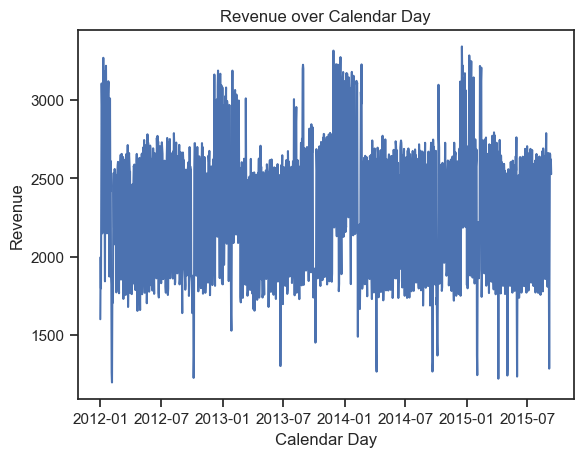

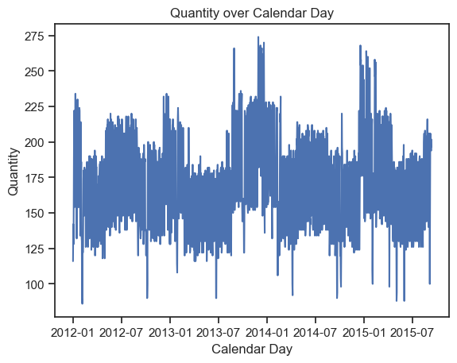

```python
# Plotting overall revenue over calendar day
sns.lineplot(x='CALENDAR_DAY', y='PRODUCT_DAILY_REVENUE', data=daily_cafe_revenue)
plt.title('Revenue over Calendar Day')
plt.xlabel('Calendar Day')
plt.ylabel('Revenue')
plt.show()

# Plotting overall quantity over calendar day
sns.lineplot(x='CALENDAR_DAY', y='QUANTITY', data=daily_cafe_revenue)
plt.title('Quantity over Calendar Day')
plt.xlabel('Calendar Day')
plt.ylabel('Quantity')
plt.show();
```

Visually, we tend to see some seasonal patterns, the colder times being a better time for business in the Cafe. The overall variance seems quite stable, both for revenue and price.

*Breakdown of sales across products?*

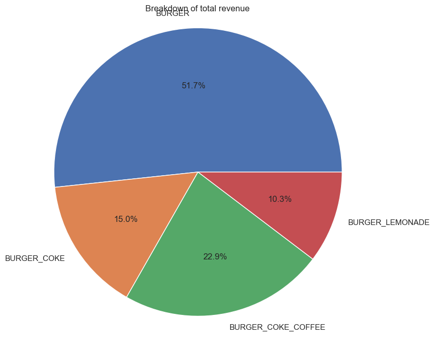

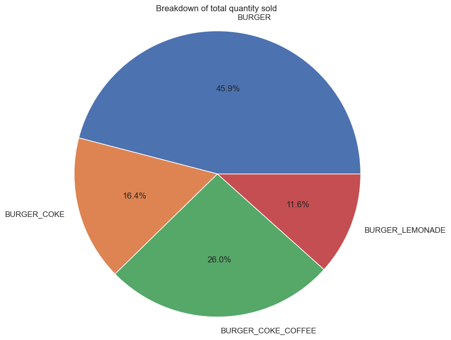

```python
# Calculate the sum of product daily revenue per product name
sum_daily_revenue_per_product = data.groupby('PRODUCT_NAME')['PRODUCT_DAILY_REVENUE'].sum()

# Plotting the pie chart
plt.figure(figsize=(8, 8))
plt.title('Breakdown of total revenue')
plt.pie(sum_daily_revenue_per_product, labels=sum_daily_revenue_per_product.index, autopct='%1.1f%%')
plt.axis('equal')  # Equal aspect ratio ensures that pie is drawn as a circle
plt.show();


# Calculate the sum of product daily revenue per product name
sum_daily_quantity_per_product = data.groupby('PRODUCT_NAME')['QUANTITY'].sum()

# Plotting the pie chart
plt.figure(figsize=(8, 8))
plt.title('Breakdown of total quantity sold')
plt.pie(sum_daily_quantity_per_product, labels=sum_daily_quantity_per_product.index, autopct='%1.1f%%')
plt.axis('equal')  # Equal aspect ratio ensures that pie is drawn as a circle
plt.show();
```

We see above that the revenue is mostly driven by the Burger, or by the Burgers (if different type of burgers are sold), but since we don't have much more context around this we will consider the Burger as a standalone product. Then comes the Burger coke coffee, the burger coke, and the burger lemonade. This may indicate for later, an order of priority, when it comes to price optimisation

```python
daily_cafe_revenue.describe()
```

|  | IS_WEEKEND | IS_SCHOOLBREAK | IS_OUTDOOR | PRODUCT_DAILY_REVENUE | QUANTITY | IS_HOLIDAY |
| --- | --- | --- | --- | --- | --- | --- |
| count | 1347.000000 | 1347.000000 | 1347.000000 | 1347.000000 | 1347.000000 | 1347.000000 |
| mean | 0.285820 | 0.204900 | 0.861915 | 2382.070883 | 177.345212 | 0.077951 |
| std | 0.451972 | 0.403778 | 0.345117 | 424.625720 | 34.205159 | 0.268194 |
| min | 0.000000 | 0.000000 | 0.000000 | 1196.560000 | 86.000000 | 0.000000 |
| 25% | 0.000000 | 0.000000 | 1.000000 | 1913.490000 | 148.000000 | 0.000000 |
| 50% | 0.000000 | 0.000000 | 1.000000 | 2535.540000 | 180.000000 | 0.000000 |
| 75% | 1.000000 | 0.000000 | 1.000000 | 2640.570000 | 204.000000 | 0.000000 |
| max | 1.000000 | 1.000000 | 1.000000 | 3343.520000 | 274.000000 | 1.000000 |

*Is there visually any association between quantity sold / revenue, and day features such as is_holiday, is_weekend, is_schoolbreak, is_outdoor?*

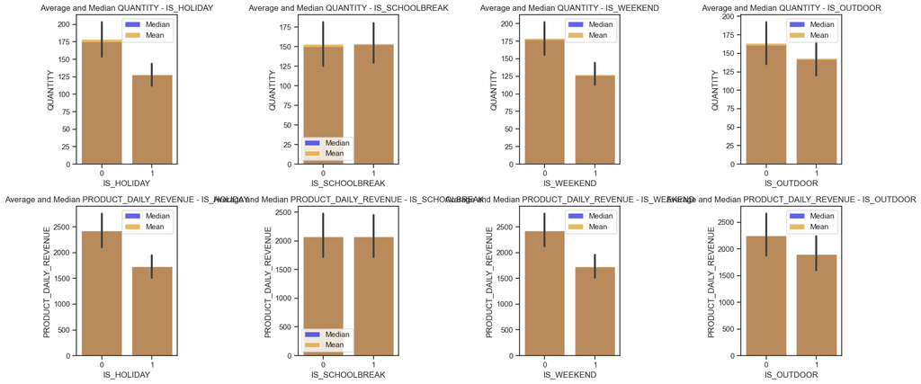

```python
# Group the data by x variables and calculate the median and mean of quantity and product daily revenue
grouped_data = daily_cafe_revenue.groupby(['IS_HOLIDAY', 'IS_SCHOOLBREAK', 'IS_WEEKEND', 'IS_OUTDOOR']).agg({'QUANTITY': ['median', 'mean'], 'PRODUCT_DAILY_REVENUE': ['median', 'mean']}).reset_index()

# Create a figure with subplots
fig, axes = plt.subplots(2, 4, figsize=(18, 8))
fig.subplots_adjust(hspace=0.4)

# Iterate over x variables and plot separate bars for median and average values for quantity and product daily revenue
x_variables = ['IS_HOLIDAY', 'IS_SCHOOLBREAK', 'IS_WEEKEND', 'IS_OUTDOOR']
y_variables = ['QUANTITY', 'PRODUCT_DAILY_REVENUE']
colors = ['blue', 'orange']

for i, x_var in enumerate(x_variables):
    for j, y_var in enumerate(y_variables):
        ax = axes[j, i]
        sns.barplot(data=grouped_data, x=x_var, y=(y_var, 'median'), color=colors[0], alpha=0.7, label='Median', ax=ax)
        sns.barplot(data=grouped_data, x=x_var, y=(y_var, 'mean'), color=colors[1], alpha=0.7, label='Mean', ax=ax)
        ax.set_xlabel(x_var)
        ax.set_ylabel(y_var)
        ax.set_title(f'Average and Median {y_var} - {x_var}')
        ax.legend()

# Hide the unused subplots
for i in range(len(x_variables), 4):
    fig.delaxes(axes[0, i])
    fig.delaxes(axes[1, i])

# Show the plot
plt.tight_layout()
plt.show();
```

*Does time, like seasonality, bring about any variance when it comes to quantity sold, for each product?*

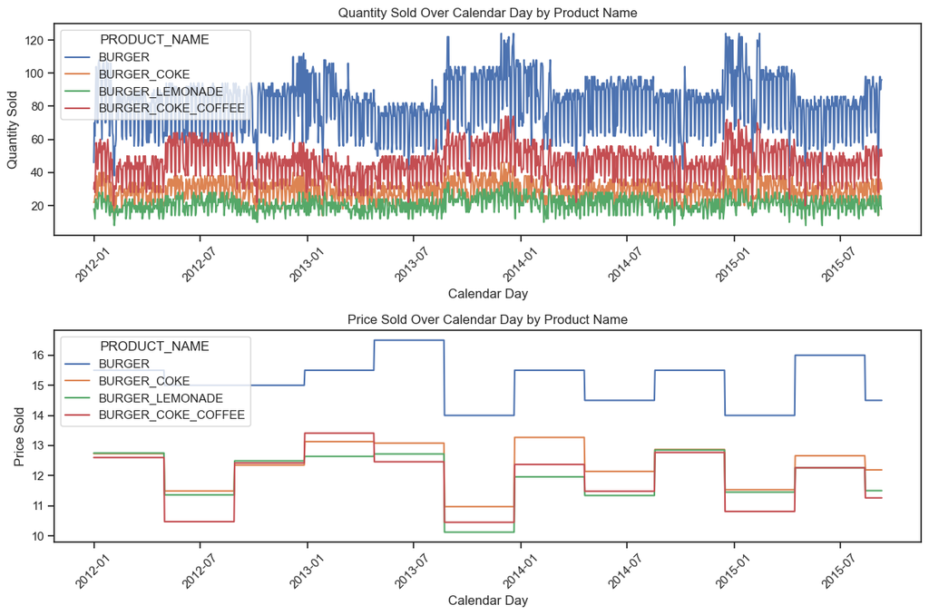

```python
# Create a figure with two subplots
fig, (ax1, ax2) = plt.subplots(2, 1, figsize=(12, 8))
fig.subplots_adjust(hspace=0.4)  # Adjust vertical spacing between subplots

# Plot quantity sold over calendar day for each product name
sns.lineplot(data=data, x='CALENDAR_DAY', y='QUANTITY', hue='PRODUCT_NAME', ax=ax1)
ax1.set(xlabel='Calendar Day', ylabel='Quantity Sold')
ax1.set_title('Quantity Sold Over Calendar Day by Product Name')

# Plot price sold over calendar day for each product name
sns.lineplot(data=data, x='CALENDAR_DAY', y='PRICE', hue='PRODUCT_NAME', ax=ax2)
ax2.set(xlabel='Calendar Day', ylabel='Price Sold')
ax2.set_title('Price Sold Over Calendar Day by Product Name')

# Rotate x-axis tick labels for better visibility
plt.setp(ax1.get_xticklabels(), rotation=45)
plt.setp(ax2.get_xticklabels(), rotation=45)

# Display the plot
plt.tight_layout()
plt.show();
```

Let's make sure of our conclusion on which products are the main ones and the priority ones to optimise for, by plotting distribution of daily revenue and quantity sold

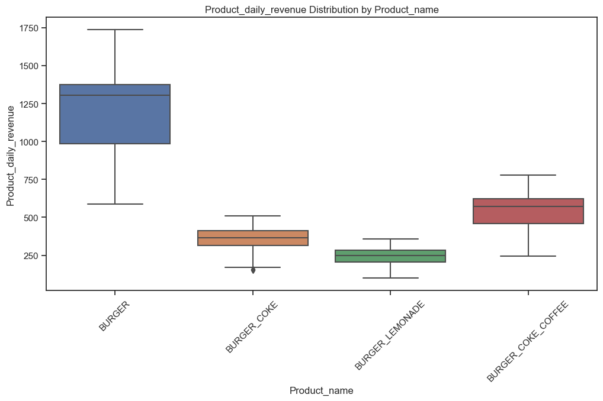

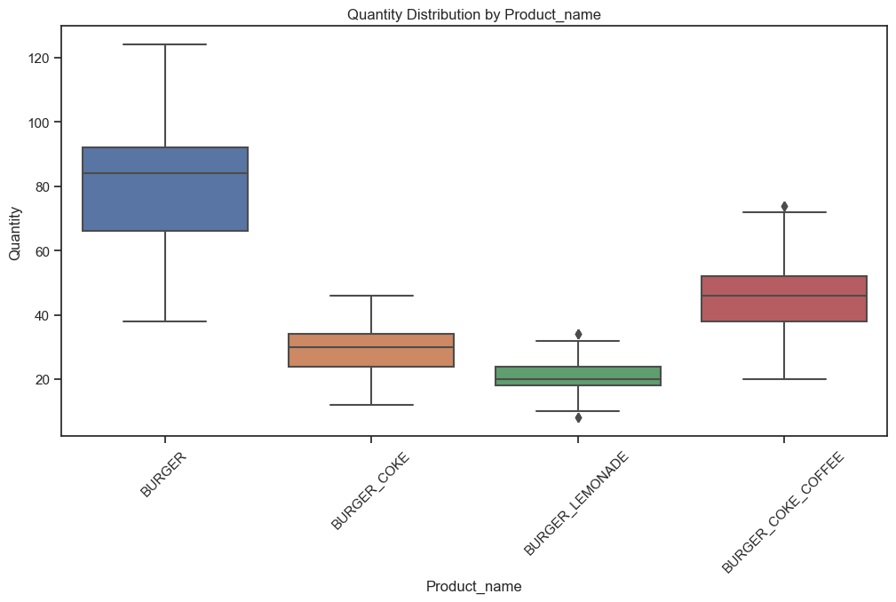

```python
def plot_boxplot_by_group(data, x, y):
    plt.figure(figsize=(12, 6))
    sns.boxplot(data=data, x=x, y=y)
    plt.xlabel(x.capitalize())
    plt.ylabel(y.capitalize())
    plt.title(f'{y.capitalize()} Distribution by {x.capitalize()}')
    plt.xticks(rotation=45)
    plt.show()

plot_boxplot_by_group(data, "PRODUCT_NAME", "PRODUCT_DAILY_REVENUE")
plot_boxplot_by_group(data, "PRODUCT_NAME", "QUANTITY")
```

There seems to be something illogical about the source data, which is that the burger itself costs more than the burger with beverages. Maybe the burger when sold by itself is of a bigger size. Or there are different burgers. Nonetheless, we will keep the data as is.

*Not all products sell the same and have similar impact on our cafe's revenue. So we will have to tackle the problem product wise. Our order of priority is: Burger, Burger Coke Coffee, Burger Coke, Burger Lemonade*

*To better estimate the expectation and variance of our yearly revenue and quantity sold, we will have to also do it per product*

## Product wise exploratory analysis. What tends to maximise quantity sold (and revenue), for every product?

### How is quantity sold distributed, product wise? Is it normally distributed?

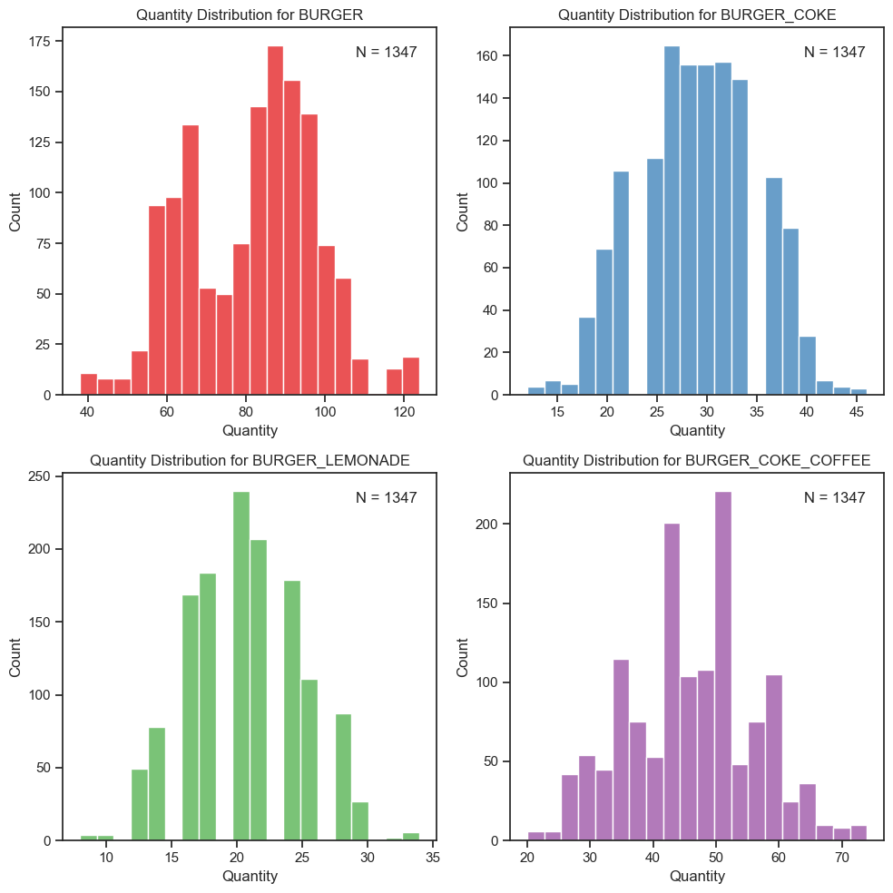

```python
unique_product_names = data['PRODUCT_NAME'].unique()
num_plots = len(unique_product_names)

fig, axes = plt.subplots(nrows=2, ncols=2, figsize=(10, 10))

colors = sns.color_palette('Set1', n_colors=num_plots)

for i, product_name in enumerate(unique_product_names):
    row = i // 2
    col = i % 2

    ax = axes[row, col]

    subset_data = data[data['PRODUCT_NAME'] == product_name]

    sns.histplot(data=subset_data, x="QUANTITY", bins=20, color=colors[i], ax=ax)
    ax.set_xlabel("Quantity")
    ax.set_ylabel('Count')
    ax.set_title(f'Quantity Distribution for {product_name}')

    num_data_points = len(subset_data)
    ax.text(0.95, 0.95, f'N = {num_data_points}', ha='right', va='top', transform=ax.transAxes)

    plt.tight_layout()

plt.show();
```

- The Burger daily quantity sold distribution seems to be the combination of two (somewhat) normal distributions, one centered aroud 65 daily Burgers sold, and another one around 90 daily Burgers sold. From above overall Cafe relationship between quantity sold and our categorical predictors, as well as the still quite high frequency for both these two distributions, I am suspecting that either the variable "IS_WEEKEND", or a variable "COLDER OR WARMER times" can explain this double normal distribution. Splitting the Burger dataset based on these criterias may potentially yield a single normal distribution.
- For more robust interpretability of a future linear regression output, it's better if the target variable distribution is close to normal
- For the other products, the distribution looks close to normal

Let's dive deeper into the Burger dataset and distribution. It is our star product, it is key to further our understanding of the behaviour of its quantity sold daily

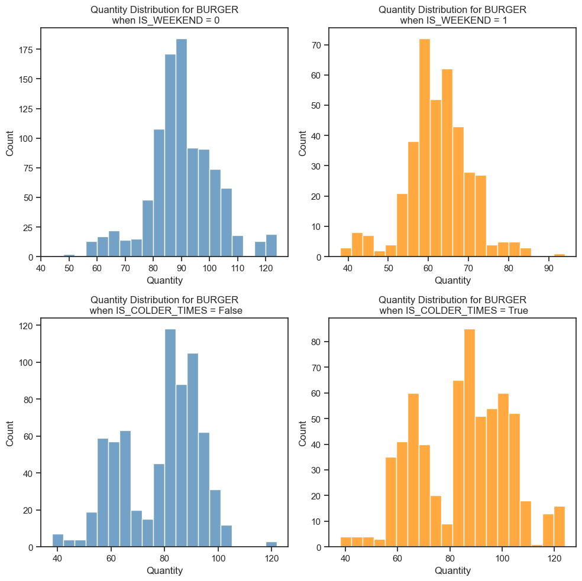

```python
#Creating a feature telling whether we are in warmer times (Q2/Q3) or colder times (Q1/Q4)

data["QUARTER"] = data["CALENDAR_DAY"].dt.quarter
data["IS_COLDER_TIMES"] = data["QUARTER"].apply(lambda x: int(x in (1,4)))

#Creating the burger dataset
burger = data[data['PRODUCT_NAME'] == 'BURGER']

#Plotting the distribution of the burger dataset, based on weekend or not, and on colder times or not

colors = ['steelblue', 'darkorange']

fig, axes = plt.subplots(nrows=2, ncols=2, figsize=(10, 10))

# Plot for IS_WEEKEND = 0
sns.histplot(data=burger[burger['IS_WEEKEND'] == 0], x="QUANTITY", bins=20, color=colors[0], ax=axes[0, 0])
axes[0, 0].set_xlabel("Quantity")
axes[0, 0].set_ylabel('Count')
axes[0, 0].set_title('Quantity Distribution for BURGER\n when IS_WEEKEND = 0')

# Plot for IS_WEEKEND = 1
sns.histplot(data=burger[burger['IS_WEEKEND'] == 1], x="QUANTITY", bins=20, color=colors[1], ax=axes[0, 1])
axes[0, 1].set_xlabel("Quantity")
axes[0, 1].set_ylabel('Count')
axes[0, 1].set_title('Quantity Distribution for BURGER\n when IS_WEEKEND = 1')

# Plot for IS_COLDER_TIMES = False
sns.histplot(data=burger[burger['IS_COLDER_TIMES'] == 0], x="QUANTITY", bins=20, color=colors[0], ax=axes[1, 0])
axes[1, 0].set_xlabel("Quantity")
axes[1, 0].set_ylabel('Count')
axes[1, 0].set_title('Quantity Distribution for BURGER\n when IS_COLDER_TIMES = False')

# Plot for IS_COLDER_TIMES = True
sns.histplot(data=burger[burger['IS_COLDER_TIMES'] == 1], x="QUANTITY", bins=20, color=colors[1], ax=axes[1, 1])
axes[1, 1].set_xlabel("Quantity")
axes[1, 1].set_ylabel('Count')
axes[1, 1].set_title('Quantity Distribution for BURGER\n when IS_COLDER_TIMES = True')

plt.tight_layout()
plt.show();
```

### The burger sells better on weekdays. Can it be because of lower prices on weekdays?

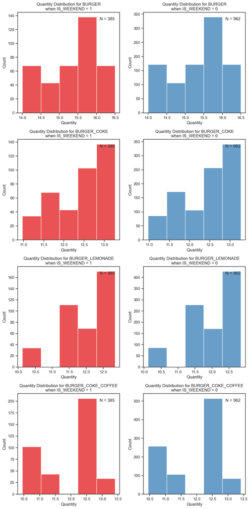

```python
##Plotting distribution of prices, per product, based on weekday or weekend

unique_product_names = data['PRODUCT_NAME'].unique()
num_plots = len(unique_product_names)

fig, axes = plt.subplots(nrows=num_plots, ncols=2, figsize=(10, 5 * num_plots))

colors = sns.color_palette('Set1', n_colors=2)

for i, product_name in enumerate(unique_product_names):
    subset_data = data[data['PRODUCT_NAME'] == product_name]

    ax1 = axes[i, 0]
    ax2 = axes[i, 1]

    sns.histplot(data=subset_data[subset_data['IS_WEEKEND'] == 1], x="PRICE", bins=5, color=colors[0], ax=ax1)
    sns.histplot(data=subset_data[subset_data['IS_WEEKEND'] == 0], x="PRICE", bins=5, color=colors[1], ax=ax2)

    ax1.set_xlabel("Quantity")
    ax1.set_ylabel('Count')
    ax1.set_title(f'Quantity Distribution for {product_name}\nwhen IS_WEEKEND = 1')
    num_data_points1 = len(subset_data[subset_data['IS_WEEKEND'] == 1])
    ax1.text(0.95, 0.95, f'N = {num_data_points1}', ha='right', va='top', transform=ax1.transAxes)

    ax2.set_xlabel("Quantity")
    ax2.set_ylabel('Count')
    ax2.set_title(f'Quantity Distribution for {product_name}\nwhen IS_WEEKEND = 0')
    num_data_points2 = len(subset_data[subset_data['IS_WEEKEND'] == 0])
    ax2.text(0.95, 0.95, f'N = {num_data_points2}', ha='right', va='top', transform=ax2.transAxes)

plt.tight_layout()
plt.show();
```

**The distribution of price given we are in a weekday or a weekend, is exactly the same across every products. It looks like simulated data, or that the products pricing decision is not taking into accoutn whether we are in a weekday or weekend. Since the prices are the same on weekend or weekday, we definitely sell better on weekdays**

There seems to be no interaction whatsoever between weekend/weekday and price, we won't use this variable later in the regression analysis